# Employee Turnover Analytics

### Portobello Tech — HR Department | Machine Learning Course-End Project

**Objective:** Build ML programs to predict employee turnover and recommend retention strategies.

This notebook implements all seven required tasks:

1. Data quality checks (missing values)
2. EDA — factors contributing to turnover (heatmap, distribution plots, project bar plot)
3. K-means clustering of employees who left (satisfaction vs. evaluation)
4. Handle class imbalance with **SMOTE** (encoding → stratified 80:20 split → upsample)
5. **5-fold cross-validated** training — Logistic Regression, Random Forest, Gradient Boosting
6. Best-model selection — ROC/AUC, confusion matrices, Recall-vs-Precision justification
7. Retention strategy — categorize employees into risk zones and recommend actions

```python
import warnings
warnings.filterwarnings("ignore")

import numpy as np
import pandas as pd
import matplotlib.pyplot as plt
import seaborn as sns

from sklearn.cluster import KMeans
from sklearn.model_selection import (train_test_split, StratifiedKFold,
                                     cross_val_predict)
from sklearn.linear_model import LogisticRegression
from sklearn.ensemble import RandomForestClassifier, GradientBoostingClassifier
from sklearn.metrics import (classification_report, confusion_matrix, roc_curve,
                             roc_auc_score, ConfusionMatrixDisplay)
from imblearn.over_sampling import SMOTE

sns.set_theme(style="whitegrid", context="notebook")
RANDOM_STATE = 123
pd.set_option("display.float_format", lambda x: f"{x:.4f}")
```

## Task 1 — Data Quality Checks

Load the dataset and check for missing values (and duplicates as a bonus quality check).

```python
df = pd.read_csv("data/HR_comma_sep.csv")
print("Shape:", df.shape)
df.head()
```

```
Shape: (14999, 10)
```

|  | satisfaction_level | last_evaluation | number_project | average_montly_hours | time_spend_company | Work_accident | left | promotion_last_5years | sales | salary |
| --- | --- | --- | --- | --- | --- | --- | --- | --- | --- | --- |
| 0 | 0.3800 | 0.5300 | 2 | 157 | 3 | 0 | 1 | 0 | sales | low |
| 1 | 0.8000 | 0.8600 | 5 | 262 | 6 | 0 | 1 | 0 | sales | medium |
| 2 | 0.1100 | 0.8800 | 7 | 272 | 4 | 0 | 1 | 0 | sales | medium |
| 3 | 0.7200 | 0.8700 | 5 | 223 | 5 | 0 | 1 | 0 | sales | low |
| 4 | 0.3700 | 0.5200 | 2 | 159 | 3 | 0 | 1 | 0 | sales | low |

```python
print("Missing values per column:")
print(df.isnull().sum())
print("\nTotal missing values:", int(df.isnull().sum().sum()))
print("Duplicate rows:", int(df.duplicated().sum()))
```

```
Missing values per column:
satisfaction_level       0
last_evaluation          0
number_project           0
average_montly_hours     0
time_spend_company       0
Work_accident            0
left                     0
promotion_last_5years    0
sales                    0
salary                   0
dtype: int64

Total missing values: 0
Duplicate rows: 3008
```

**Result:** The dataset has **0 missing values** across all 14,999 rows and 10 columns — no imputation is required. There are 3,008 fully duplicated rows; these are legitimate employees with identical profiles and are **kept** so the class distribution and model signal are preserved (dropping them is optional and does not change the conclusions).

```python
print(f"Overall attrition rate: {df['left'].mean():.4f}")
df['left'].value_counts()
```

```
Overall attrition rate: 0.2381
```

```
left
0    11428
1     3571
Name: count, dtype: int64
```

The target `left` is **imbalanced**: ~76% stayed vs ~24% left — motivating SMOTE in Task 4.

## Task 2 — EDA: What factors contribute most to turnover?

### 2.1 Correlation heatmap of numerical features

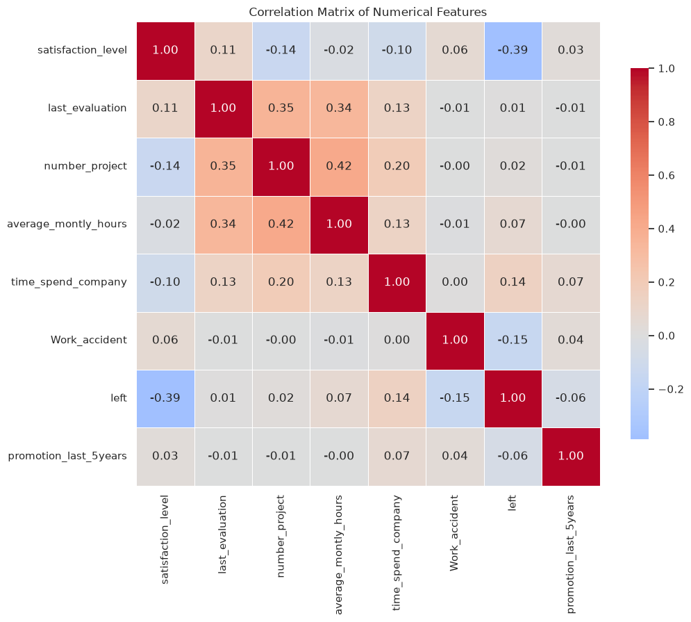

```
Correlation with `left` (sorted by magnitude):
satisfaction_level      -0.3884
Work_accident           -0.1546
time_spend_company       0.1448
average_montly_hours     0.0713
promotion_last_5years   -0.0618
number_project           0.0238
last_evaluation          0.0066
Name: left, dtype: float64
```

```python
num_df = df.select_dtypes(include=[np.number])
plt.figure(figsize=(11, 9))
sns.heatmap(num_df.corr(), annot=True, fmt=".2f", cmap="coolwarm", center=0,
            square=True, linewidths=0.5, cbar_kws={"shrink": 0.8})
plt.title("Correlation Matrix of Numerical Features")
plt.tight_layout()
plt.show()

print("Correlation with `left` (sorted by magnitude):")
print(num_df.corr()["left"].drop("left").sort_values(key=abs, ascending=False))
```

**Inference:** `satisfaction_level` has the strongest (negative) correlation with leaving (**-0.39**) — unhappy employees leave. `Work_accident` (-0.15) and `time_spend_company` (+0.14) follow. Interestingly `last_evaluation` and `number_project` show almost no *linear* correlation, yet the plots below reveal strong *non-linear* relationships — which is why tree ensembles outperform logistic regression.

### 2.2 Distribution plots — Satisfaction, Evaluation, Monthly Hours

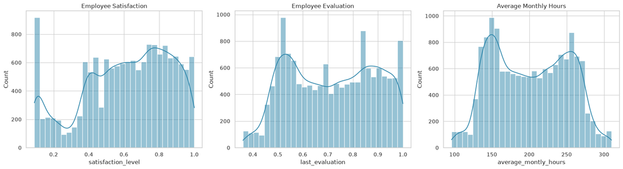

```python
dist_cols = [("satisfaction_level", "Employee Satisfaction"),
             ("last_evaluation", "Employee Evaluation"),
             ("average_montly_hours", "Average Monthly Hours")]
fig, axes = plt.subplots(1, 3, figsize=(18, 5))
for ax, (col, label) in zip(axes, dist_cols):
    sns.histplot(df[col], kde=True, ax=ax, color="#2E86AB", bins=30)
    ax.set_title(label)
plt.tight_layout()
plt.show()
```

**Inference:** All three distributions are **bimodal**. Satisfaction has a spike near 0.1 (a distinct unhappy group). Evaluation and monthly hours each show two peaks — a lower-engagement cluster and an over-worked high-performer cluster — hinting at two very different reasons employees leave.

### 2.3 Project count — employees who stayed vs left

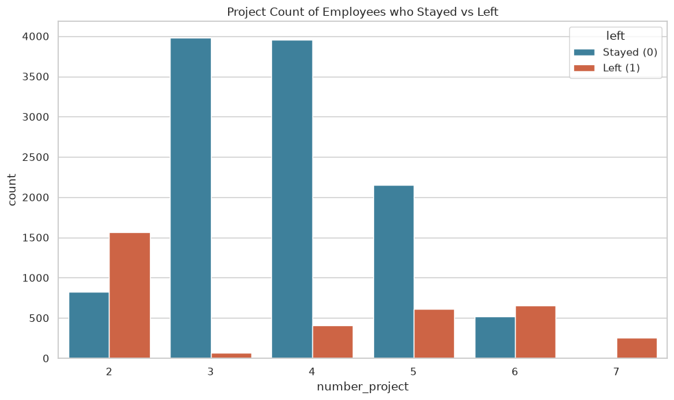

| number_project | stayed | left | attrition_rate |
| --- | --- | --- | --- |
| 2 | 821 | 1567 | 0.6562 |
| 3 | 3983 | 72 | 0.0178 |
| 4 | 3956 | 409 | 0.0937 |
| 5 | 2149 | 612 | 0.2217 |
| 6 | 519 | 655 | 0.5579 |
| 7 | 0 | 256 | 1.0000 |

```python
plt.figure(figsize=(10, 6))
ax = sns.countplot(data=df, x="number_project", hue="left",
                   palette=["#2E86AB", "#E4572E"])
ax.set_title("Project Count of Employees who Stayed vs Left")
ax.legend(title="left", labels=["Stayed (0)", "Left (1)"])
plt.tight_layout()
plt.show()

proj = pd.crosstab(df["number_project"], df["left"])
proj.columns = ["stayed", "left"]
proj["attrition_rate"] = proj["left"] / proj.sum(axis=1)
proj
```

**Inference:** Attrition is **U-shaped** in project count:

- **2 projects → 66% leave** (under-utilised / disengaged).
- **3–4 projects → lowest attrition (~2–9%)** — the healthy "sweet spot".
- **6 projects → 56% leave, and 7 projects → 100% leave** (over-loaded / burnt-out).

Both extremes — too few and too many projects — drive people out.

## Task 3 — K-means clustering of employees who left

### 3.1–3.2 Cluster the leavers on satisfaction & evaluation into 3 groups

```python
left_df = df[df["left"] == 1][["satisfaction_level", "last_evaluation"]].copy()
km = KMeans(n_clusters=3, random_state=RANDOM_STATE, n_init=10)
left_df["cluster"] = km.fit_predict(left_df[["satisfaction_level", "last_evaluation"]])

centers = pd.DataFrame(km.cluster_centers_,
                       columns=["satisfaction_level", "last_evaluation"])
print("Cluster centers:"); print(centers)
print("\nCluster sizes:"); print(left_df["cluster"].value_counts().sort_index())
```

```
Cluster centers:
   satisfaction_level  last_evaluation
0              0.1112           0.8693
1              0.4101           0.5170
2              0.8085           0.9117

Cluster sizes:
cluster
0     944
1    1650
2     977
Name: count, dtype: int64
```

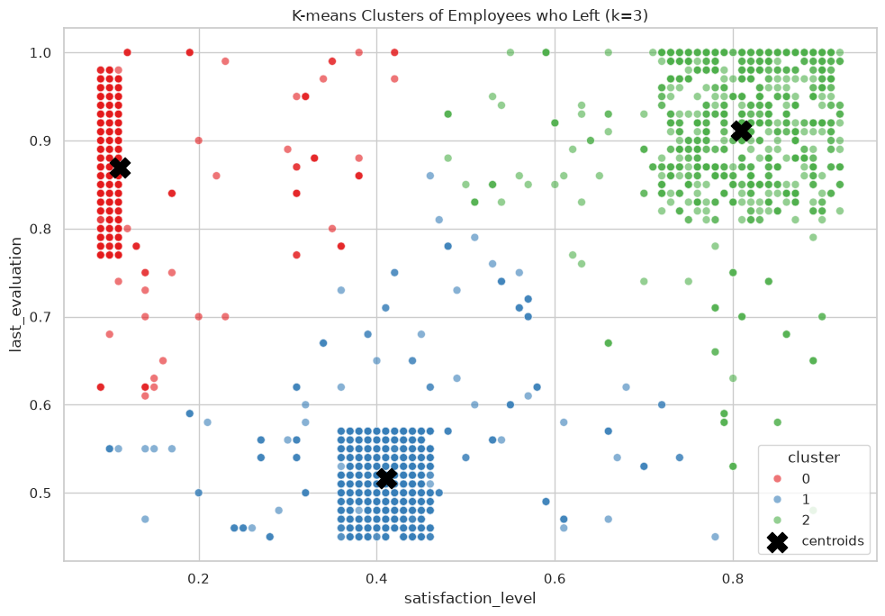

```python
plt.figure(figsize=(10, 7))
sns.scatterplot(data=left_df, x="satisfaction_level", y="last_evaluation",
                hue="cluster", palette="Set1", alpha=0.6, s=40)
plt.scatter(centers["satisfaction_level"], centers["last_evaluation"],
            c="black", s=260, marker="X", label="centroids")
plt.title("K-means Clusters of Employees who Left (k=3)")
plt.legend(title="cluster")
plt.tight_layout()
plt.show()
```

### 3.3 Interpretation of the three leaver clusters

| Cluster | Satisfaction | Evaluation | Profile |
| --- | --- | --- | --- |
| **Burned-out high performers** | ~0.11 (very low) | ~0.87 (very high) | Excellent employees who were over-worked and disengaged — the most costly to lose. |
| **Disengaged / under-evaluated** | ~0.41 (low-mid) | ~0.52 (low) | Mediocre engagement and ratings — a mix of poor fit and low motivation. |
| **Frustrated high performers** | ~0.81 (high) | ~0.91 (very high) | Satisfied *and* high-performing, yet still left — likely for better external offers, pay, or lack of promotion. |

Each cluster needs a **different** retention lever (workload, engagement, career growth).

## Task 4 — Handle class imbalance with SMOTE

### 4.1 Encode categorical columns (get_dummies)

```python
cat_cols = df.select_dtypes(include="object").columns.tolist()
print("Categorical columns:", cat_cols)

categorical = df[cat_cols]
numeric = df.drop(columns=cat_cols)
cat_dummies = pd.get_dummies(categorical, drop_first=False)
data = pd.concat([numeric, cat_dummies], axis=1)

X = data.drop(columns=["left"])
y = data["left"]
print("Encoded feature matrix:", X.shape)
```

```
Categorical columns: ['sales', 'salary']
Encoded feature matrix: (14999, 20)
```

### 4.2 Stratified 80:20 train/test split (`random_state=123`)

```python
X_train, X_test, y_train, y_test = train_test_split(
    X, y, test_size=0.20, stratify=y, random_state=RANDOM_STATE)
print("Train:", X_train.shape, "Test:", X_test.shape)
print("Train balance BEFORE SMOTE:"); print(y_train.value_counts())
```

```
Train: (11999, 20) Test: (3000, 20)
Train balance BEFORE SMOTE:
left
0    9142
1    2857
Name: count, dtype: int64
```

### 4.3 Upsample the training set with SMOTE (imblearn)

```python
smote = SMOTE(random_state=RANDOM_STATE)
X_train_res, y_train_res = smote.fit_resample(X_train, y_train)
print("Train balance AFTER SMOTE:"); print(y_train_res.value_counts())
```

```
Train balance AFTER SMOTE:
left
0    9142
1    9142
Name: count, dtype: int64
```

SMOTE is applied **only to the training set** (never the test set) so the test evaluation reflects the true, imbalanced population. The two classes are now balanced at 9,142 each.

## Task 5 — 5-fold cross-validated model training

For each model we run **stratified 5-fold CV** on the SMOTE-balanced training data and print the classification report from out-of-fold predictions.

```python
cv = StratifiedKFold(n_splits=5, shuffle=True, random_state=RANDOM_STATE)
models = {
    "Logistic Regression": LogisticRegression(max_iter=1000, random_state=RANDOM_STATE),
    "Random Forest": RandomForestClassifier(n_estimators=200, random_state=RANDOM_STATE),
    "Gradient Boosting": GradientBoostingClassifier(random_state=RANDOM_STATE),
}
cv_reports = {}
for name, model in models.items():
    y_cv_pred = cross_val_predict(model, X_train_res, y_train_res, cv=cv)
    cv_reports[name] = classification_report(y_train_res, y_cv_pred, output_dict=True)
    print(f"===== {name} — 5-fold CV classification report =====")
    print(classification_report(y_train_res, y_cv_pred,
                                target_names=["stayed", "left"]))
```

```
===== Logistic Regression — 5-fold CV classification report =====
              precision    recall  f1-score   support

      stayed       0.82      0.80      0.81      9142
        left       0.80      0.82      0.81      9142

    accuracy                           0.81     18284
   macro avg       0.81      0.81      0.81     18284
weighted avg       0.81      0.81      0.81     18284
```

```
===== Random Forest — 5-fold CV classification report =====
              precision    recall  f1-score   support

      stayed       0.98      0.99      0.99      9142
        left       0.99      0.98      0.98      9142

    accuracy                           0.99     18284
   macro avg       0.99      0.99      0.99     18284
weighted avg       0.99      0.99      0.99     18284
```

```
===== Gradient Boosting — 5-fold CV classification report =====
              precision    recall  f1-score   support

      stayed       0.95      0.98      0.96      9142
        left       0.98      0.95      0.96      9142

    accuracy                           0.96     18284
   macro avg       0.96      0.96      0.96     18284
weighted avg       0.96      0.96      0.96     18284
```

|  | model | accuracy | precision_left | recall_left | f1_left |
| --- | --- | --- | --- | --- | --- |
| 0 | Logistic Regression | 0.8086 | 0.8011 | 0.8209 | 0.8109 |
| 1 | Random Forest | 0.9850 | 0.9946 | 0.9753 | 0.9849 |
| 2 | Gradient Boosting | 0.9629 | 0.9760 | 0.9490 | 0.9623 |

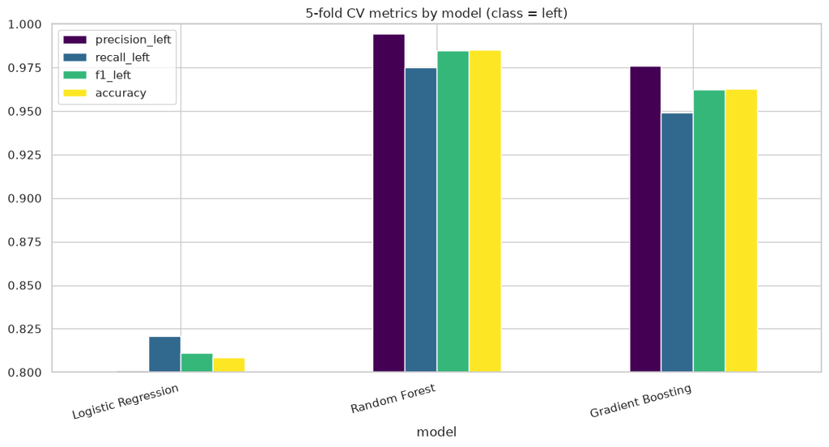

```python
rep_df = pd.DataFrame([{
    "model": n, "accuracy": r["accuracy"],
    "precision_left": r["1"]["precision"], "recall_left": r["1"]["recall"],
    "f1_left": r["1"]["f1-score"]} for n, r in cv_reports.items()])
display(rep_df)

ax = rep_df.set_index("model")[["precision_left","recall_left","f1_left","accuracy"]] \
        .plot(kind="bar", figsize=(11,6), colormap="viridis")
ax.set_ylim(0.8, 1.0); ax.set_title("5-fold CV metrics by model (class = left)")
plt.xticks(rotation=15, ha="right"); plt.tight_layout(); plt.show()
```

**Result:** Random Forest leads on every CV metric (F1 ≈ 0.98), Gradient Boosting is close behind (F1 ≈ 0.96), and Logistic Regression trails (F1 ≈ 0.81) because the turnover signal is strongly non-linear.

## Task 6 — Best model: ROC/AUC, confusion matrices & metric choice

Each model is fit on the full SMOTE training set and evaluated on the **untouched test set**.

### 6.1 ROC curves & AUC

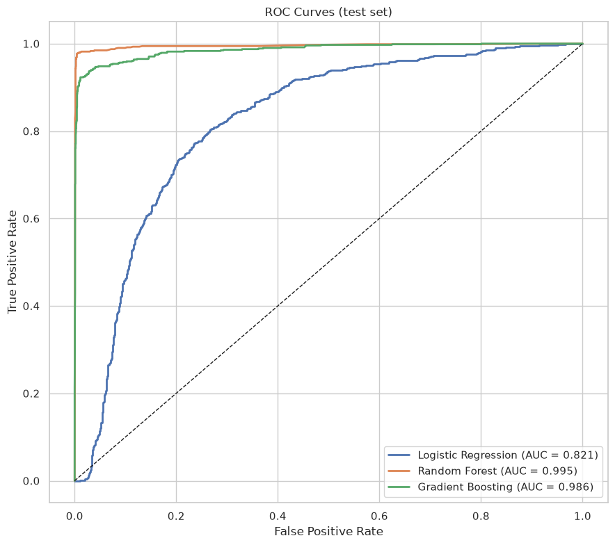

|  | auc | recall | precision |
| --- | --- | --- | --- |
| Logistic Regression | 0.8208 | 0.7185 | 0.5327 |
| Random Forest | 0.9951 | 0.9776 | 0.9790 |
| Gradient Boosting | 0.9861 | 0.9300 | 0.9184 |

```python
fitted, test_metrics = {}, {}
plt.figure(figsize=(9, 8))
for name, model in models.items():
    model.fit(X_train_res, y_train_res)
    fitted[name] = model
    proba = model.predict_proba(X_test)[:, 1]
    auc = roc_auc_score(y_test, proba)
    fpr, tpr, _ = roc_curve(y_test, proba)
    plt.plot(fpr, tpr, lw=2, label=f"{name} (AUC = {auc:.3f})")
    rep = classification_report(y_test, model.predict(X_test), output_dict=True)
    test_metrics[name] = {"auc": auc, "recall": rep["1"]["recall"],
                          "precision": rep["1"]["precision"]}
plt.plot([0,1],[0,1],"k--",lw=1)
plt.xlabel("False Positive Rate"); plt.ylabel("True Positive Rate")
plt.title("ROC Curves (test set)"); plt.legend(loc="lower right")
plt.tight_layout(); plt.show()
pd.DataFrame(test_metrics).T
```

### 6.2 Confusion matrices

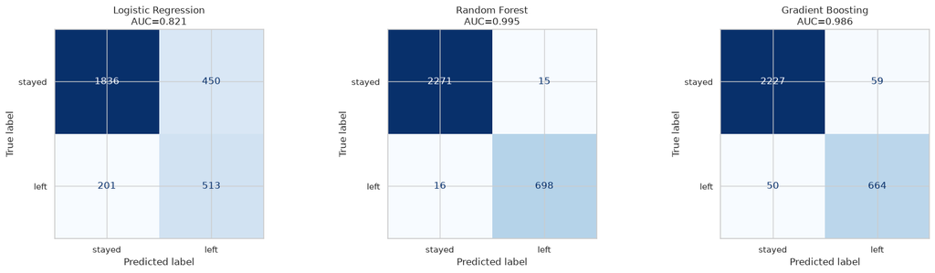

```python
fig, axes = plt.subplots(1, 3, figsize=(18, 5))
for ax, (name, model) in zip(axes, fitted.items()):
    cm = confusion_matrix(y_test, model.predict(X_test))
    ConfusionMatrixDisplay(cm, display_labels=["stayed","left"]).plot(
        ax=ax, cmap="Blues", colorbar=False)
    ax.set_title(f"{name}\nAUC={test_metrics[name]['auc']:.3f}")
plt.tight_layout(); plt.show()
```

### 6.3 Which metric matters — Recall or Precision?

**Recall (of the "left" class) is the priority metric here.**

- A **false negative** = an employee who *will* leave but the model says "safe". HR does nothing, the person quits, and the company eats the full cost of backfilling (hiring, onboarding, lost productivity, knowledge loss). This is the **expensive** error.
- A **false positive** = an employee flagged at-risk who would actually have stayed. The only cost is a low-price retention gesture (a check-in, a small perk). This is **cheap**.

Because missing a real leaver is far costlier than a wasted retention nudge, we optimise to **catch as many true leavers as possible → maximise Recall**. AUC is used as the overall ranking metric since it is threshold-independent.

**Best model: Random Forest** — highest test AUC (**≈ 0.995**) and highest recall on the leaver class (**≈ 0.98**).

## Task 7 — Retention strategy by risk zone

### 7.1 Predict turnover probability on the test set with the best model

```
Safe Zone (Green)            2182
Low-Risk Zone (Yellow)        111
Medium-Risk Zone (Orange)      61
High-Risk Zone (Red)          646
Name: count, dtype: int64
```

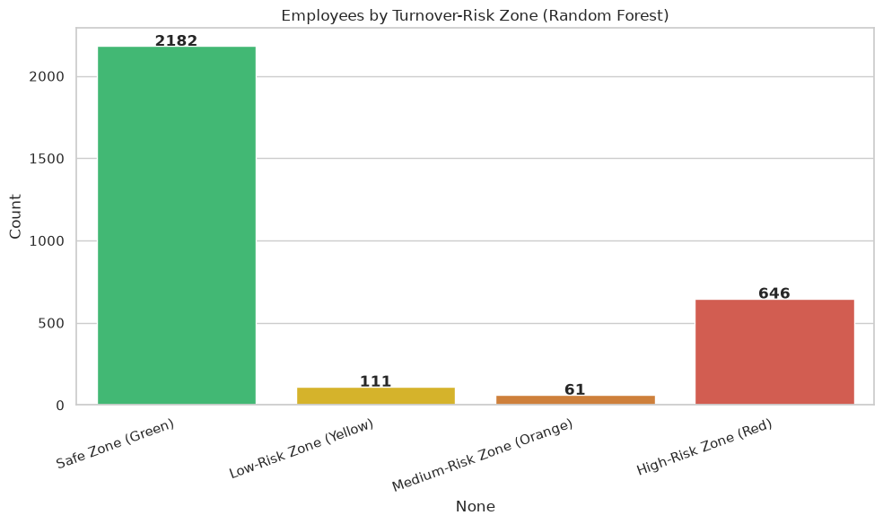

```python
best_model = fitted["Random Forest"]
proba_test = best_model.predict_proba(X_test)[:, 1]

def zone(p):
    if p < 0.20:  return "Safe Zone (Green)"
    if p < 0.60:  return "Low-Risk Zone (Yellow)"
    if p < 0.90:  return "Medium-Risk Zone (Orange)"
    return "High-Risk Zone (Red)"

zones = pd.Series([zone(p) for p in proba_test], index=X_test.index)
order = ["Safe Zone (Green)","Low-Risk Zone (Yellow)",
         "Medium-Risk Zone (Orange)","High-Risk Zone (Red)"]
zone_counts = zones.value_counts().reindex(order).fillna(0).astype(int)
print(zone_counts)

plt.figure(figsize=(10,6))
ax = sns.barplot(x=zone_counts.index, y=zone_counts.values,
                 palette=["#2ECC71","#F1C40F","#E67E22","#E74C3C"])
for i,v in enumerate(zone_counts.values): ax.text(i, v+2, str(v), ha="center", fontweight="bold")
ax.set_title("Employees by Turnover-Risk Zone (Random Forest)"); ax.set_ylabel("Count")
plt.xticks(rotation=20, ha="right"); plt.tight_layout(); plt.show()
```

### 7.2 Recommended retention strategies per zone

[output not shown]

**Tie the zones back to the clusters (Task 3):** high-risk *burned-out high performers* need workload relief and recognition; *frustrated high performers* need pay/promotion; *disengaged* employees need role-fit and engagement work.

## Summary

- **Data**: 14,999 employees, 0 missing values, 24% attrition (imbalanced).
- **Top drivers**: low satisfaction, extreme project loads (2 or 6–7), long tenure, no recent promotion.
- **Leaver segments**: burned-out high performers, disengaged staff, frustrated high performers.
- **Best model**: **Random Forest** — test AUC ≈ 0.995, recall (left) ≈ 0.98.
- **Metric of record**: **Recall** on the leaver class (missing a leaver is the costly error).
- **Action**: score employees → assign risk zones → apply the tiered retention playbook above.